# Dimensionality Reduction with PCA - Visualization

Boston Housing Dataset

Let us load the `tidyverse` package for data transformation and visualization

```r
library(tidyverse)
```

## House Prices in Boston

For each neighborhood, a number of variables are given, such as the crime rate, the student/teacher ratio, and the median value of a housing unit in the neighborhood.

The file `BostonHousing.csv` contains information collected by the US Bureau of the Census concerning housing in the area of Boston, Massachusetts. The dataset includes information on 506 census housing tracts in the Boston area. The goal is to *predict the median house price* in new tracts based on information such as crime rate, pollution, and number of rooms. The response is the median house price (`MEDV`).

| Variables | Description |
| --- | --- |
| `CRIM` | Crime rate |
| `ZN` | Percentage of residential land zoned for lots over 25,000 ft2 |
| `INDUS` | Percentage of land occupied by non-retail business |
| `CHAS` | Does tract bound Charles River (`= 1` if tract bounds river, `= 0` otherwise) |
| `NOX` | Nitric oxide concentration (parts per 10 million) |
| `RM` | Average number of rooms per dwelling |
| `AGE` | Percentage of owner-occupied units built prior to 1940 |
| `DIS` | Weighted distances to five Boston employment centers |
| `RAD` | Index of accessibility to radial highways |
| `TAX` | Full-value property tax rate per $10,000 |
| `PTRATIO` | Pupil-to-teacher ratio by town |
| `LSTAT` | Percentage of lower status of the population |
| `MEDV` | Median value of owner-occupied homes in $1000s |
| `CAT.MEDV` | Is median value of owner-occupied homes in tract above $30,000 (`CAT.MEDV = 1`) or not (`CAT.MEDV = 0`) |

- Read dataset:

```r
housing <- read_csv("https://raw.githubusercontent.com/reisanar/datasets/master/BostonHousing.csv")
```

Print the first 6 observations:

```r
head(housing)
```

| CRIM | ZN | INDUS | CHAS | NOX | RM | AGE | DIS | RAD | TAX | PTRATIO | LSTAT | MEDV | CAT_MEDV |
| --- | --- | --- | --- | --- | --- | --- | --- | --- | --- | --- | --- | --- | --- |
| 0.00632 | 18 | 2.31 | 0 | 0.538 | 6.575 | 65.2 | 4.0900 | 1 | 296 | 15.3 | 4.98 | 24.0 | 0 |
| 0.02731 | 0 | 7.07 | 0 | 0.469 | 6.421 | 78.9 | 4.9671 | 2 | 242 | 17.8 | 9.14 | 21.6 | 0 |
| 0.02729 | 0 | 7.07 | 0 | 0.469 | 7.185 | 61.1 | 4.9671 | 2 | 242 | 17.8 | 4.03 | 34.7 | 1 |
| 0.03237 | 0 | 2.18 | 0 | 0.458 | 6.998 | 45.8 | 6.0622 | 3 | 222 | 18.7 | 2.94 | 33.4 | 1 |
| 0.06905 | 0 | 2.18 | 0 | 0.458 | 7.147 | 54.2 | 6.0622 | 3 | 222 | 18.7 | 5.33 | 36.2 | 1 |
| 0.02985 | 0 | 2.18 | 0 | 0.458 | 6.430 | 58.7 | 6.0622 | 3 | 222 | 18.7 | 5.21 | 28.7 | 0 |

The first row represents the first neighborhood, which had an average per capita crime rate of 0.006, 18% of the residential land zoned for lots over 25,000 ft2, 2.31% of the land devoted to non-retail business, no border on the Charles River, and so on.

Let us consider a smaller data set of continuous variables only:

```r
red_boston <- housing %>%
                select(-c(ZN, RAD, TAX, CHAS, CAT_MEDV))
```

Are there any missing values?

```r
red_boston %>%
  is.na() %>%
  sum()
```

```
[1] 0
```

Luckily, this dataset has no missing values. We now focus on performing PCA using all numerical variables in the `red_boston` data frame:

#### Other summaries

We can also compute the standard deviation, which gives a sense of how dispersed the data are (relative to the mean). Further options, such as `sum(is.na(VARIABLE))`, which gives the number of null values, can tell us about missing values.

```r
# data frame with summary statistics
tibble(
    var_name   = colnames(housing),
    var_mean   = map_dbl(housing, mean),
    var_sd     = map_dbl(housing, sd),
    var_median = map_dbl(housing, median),
    var_miss   = map_dbl(housing, ~sum(is.na(.)))
    )
```

| var_name | var_mean | var_sd | var_median | var_miss |
| --- | --- | --- | --- | --- |
| CRIM | 3.61352356 | 8.6015451 | 0.25651 | 0 |
| ZN | 11.36363636 | 23.3224530 | 0.00000 | 0 |
| INDUS | 11.13677866 | 6.8603529 | 9.69000 | 0 |
| CHAS | 0.06916996 | 0.2539940 | 0.00000 | 0 |
| NOX | 0.55469506 | 0.1158777 | 0.53800 | 0 |
| RM | 6.28463439 | 0.7026171 | 6.20850 | 0 |
| AGE | 68.57490119 | 28.1488614 | 77.50000 | 0 |
| DIS | 3.79504269 | 2.1057101 | 3.20745 | 0 |
| RAD | 9.54940711 | 8.7072594 | 5.00000 | 0 |
| TAX | 408.23715415 | 168.5371161 | 330.00000 | 0 |

[output cut: 4 more lines]

#### Correlation

Next, we summarize relationships between two or more variables.

For *numerical variables*, we can compute a complete **matrix of correlations** between each pair of variables, using the R function `cor()`.

```r
# matrix with correlation coefficients
cor(red_boston)
```

```
              CRIM      INDUS        NOX         RM        AGE        DIS    PTRATIO      LSTAT       MEDV
CRIM     1.0000000  0.4065834  0.4209717 -0.2192467  0.3527343 -0.3796701  0.2899456  0.4556215 -0.3883046
INDUS    0.4065834  1.0000000  0.7636514 -0.3916759  0.6447785 -0.7080270  0.3832476  0.6037997 -0.4837252
NOX      0.4209717  0.7636514  1.0000000 -0.3021882  0.7314701 -0.7692301  0.1889327  0.5908789 -0.4273208
RM      -0.2192467 -0.3916759 -0.3021882  1.0000000 -0.2402649  0.2052462 -0.3555015 -0.6138083  0.6953599
AGE      0.3527343  0.6447785  0.7314701 -0.2402649  1.0000000 -0.7478805  0.2615150  0.6023385 -0.3769546
DIS     -0.3796701 -0.7080270 -0.7692301  0.2052462 -0.7478805  1.0000000 -0.2324705 -0.4969958  0.2499287
PTRATIO  0.2899456  0.3832476  0.1889327 -0.3555015  0.2615150 -0.2324705  1.0000000  0.3740443 -0.5077867
LSTAT    0.4556215  0.6037997  0.5908789 -0.6138083  0.6023385 -0.4969958  0.3740443  1.0000000 -0.7376627
MEDV    -0.3883046 -0.4837252 -0.4273208  0.6953599 -0.3769546  0.2499287 -0.5077867 -0.7376627  1.0000000
```

### PCA

We use the `prcomp()` function to perform principal component analysis (PCA) on the Boston housing dataset:

```r
pca_boston <- prcomp(red_boston, scale = T)
# summary
summary(pca_boston)
```

```
Importance of components:
                          PC1    PC2     PC3     PC4     PC5     PC6     PC7     PC8     PC9
Standard deviation     2.1897 1.2194 0.88062 0.82777 0.62255 0.55048 0.46566 0.44013 0.39580
Proportion of Variance 0.5327 0.1652 0.08617 0.07613 0.04306 0.03367 0.02409 0.02152 0.01741
Cumulative Proportion  0.5327 0.6979 0.78411 0.86024 0.90331 0.93698 0.96107 0.98259 1.00000
```

The first 5 principal component explain ~90% of the variation in the collection of 506 data points.

We can check the loadings for these 5 components:

```r
# check the new loadings
pca_boston$rotation[ , 1:5]
```

```
               PC1          PC2         PC3         PC4         PC5
CRIM     0.2653555  0.005326466  0.69615209 -0.63199277 -0.09225548
INDUS    0.3858040 -0.161284875 -0.02754606  0.17735055 -0.52587819
NOX      0.3776718 -0.315809534 -0.13507662 -0.05651541 -0.18264780
RM      -0.2721135 -0.486149250  0.40513709  0.10361741  0.35581083
AGE      0.3591693 -0.313625989 -0.09037383  0.12853860  0.58955195
DIS     -0.3473877  0.415947651  0.01111363 -0.14784380  0.11806503
PTRATIO  0.2322728  0.356013692  0.53264090  0.68418539  0.03822821
LSTAT    0.3863031  0.183393397 -0.17524468 -0.20216886  0.40169556
MEDV    -0.3334643 -0.454014830  0.09758974  0.08854101 -0.17506546
```

*Can we characterize the role of each principal component here?*

- PC1 largest loadings come from `LSTAT` (percentage of lower status of the population) , `INDUS` (percentage of land occupied by non-retail business), `NOX` (nitric oxide concentration)
- PC2 largest loadings come from (positive) `DIS` (weighted distances to 5 Boston employment centers), and (negative) `MEDV` (median value of owner-occupied homes), (negative) `RM` (average number of rooms)

### Visualization

**Using `factoextra`**

The `factoextra` package provides some easy-to-use functions to extract and visualize the output of multivariate data analyses, including Principal Component Analysis (PCA)

```r
library(factoextra)
```

A *scree-plot* can be easily generated to show the contribution of each component to explain the variation in the data

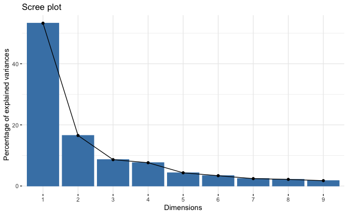

```r
fviz_screeplot(pca_boston)
```

Biplots can also be generated using:

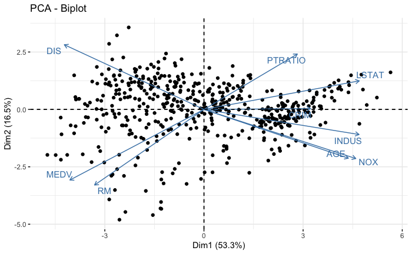

```r
fviz_pca(pca_boston,
         geom = "point",
         repel = TRUE)
```

Contributions to the first principal component:

```r
pca_boston$rotation[ , 1]
```

```
      CRIM      INDUS        NOX         RM        AGE        DIS    PTRATIO      LSTAT       MEDV
 0.2653555  0.3858040  0.3776718 -0.2721135  0.3591693 -0.3473877  0.2322728  0.3863031 -0.3334643
```

Contributions to the second principal component:

```r
pca_boston$rotation[ , 2]
```

```
        CRIM        INDUS          NOX           RM          AGE          DIS      PTRATIO        LSTAT         MEDV
 0.005326466 -0.161284875 -0.315809534 -0.486149250 -0.313625989  0.415947651  0.356013692  0.183393397 -0.454014830
```